# Part II - (Used Car Dataset)

## by (Joseph Njuguna)

## Investigation Overview

This document explores the relationship between the selling price of a used car and its production year,kilometers_driven,fuel type,seller_type ,transmission type and ownership type. From the exploratory phase, we have been able to gather the below insights from the dataset.

## Dataset Overview

The dataset contains the features name,year,selling price,km_driven,fuel,seller_type transmission and owner details of used cars. We have 7887 records in the dataset.

### Selling Price Distribution

We have noted that the selling price is skewed to the right, due to the high values of upto 120000 dollars.Second plot x axis has been limited to 20000 dollars so that we can be able to see the selling price distribution.The distribution is unimodal with most of the used cars, costing less than 10000$.

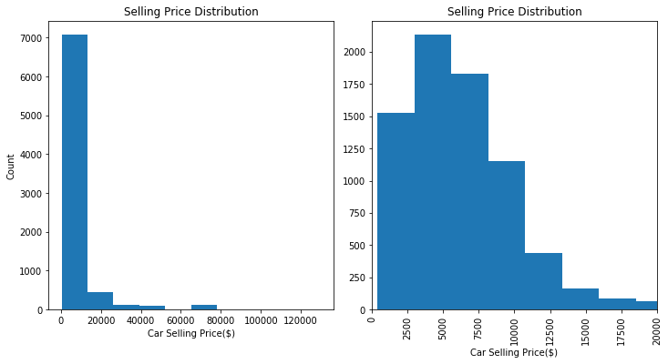

### Selling Price vs Kilometers Driven

Values for the km_driven feature range between 0 and 600000km.A majority of the cars have done less than 200,000km. We further note that the relationship between Selling Price and Kilometers driven is negatively correlated.

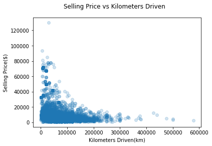

### Selling Price vs Mileage

From the below visualization,we do not see a clear correlation between Selling Price and Mileage.

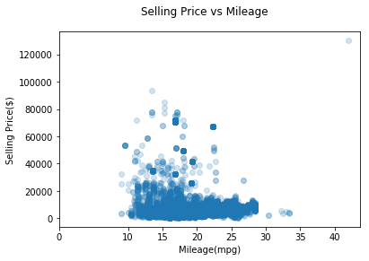

### Selling Price vs Engine Size

We note that selling price is positively correlated to Engine Size. As the engine Size increase, the selling price also increases.

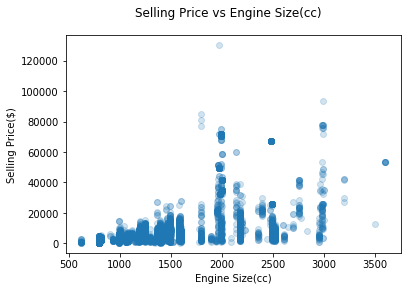

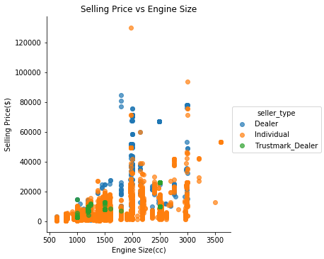

### Selling Price vs Maximum Power

We have noted a positive correlation between Selling Price and Maximum Horse Power of a used car

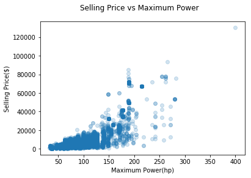

### Selling Price vs Year

From the visualization of Selling Price vs Year, we note that among the top 7 models, we note that in top 4 models in this group,the selling price has been increasing gradually over the years.For the last 2 models in this group of 7 , we noted a price decrease,however we do not have records of these cars for recent years.When we focus on models produced from 2007 to present, we have noted an updward trend in price across the top 4 models. We can therefore state that more recent models of used cars have a higher selling price compared to older cars of the same model.

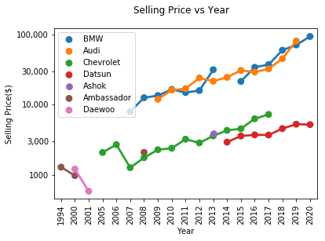

### Maximum Horse Power vs Engine Size

From our visualization, we note that there is a positive correlation between Engine Size and Maximum Power

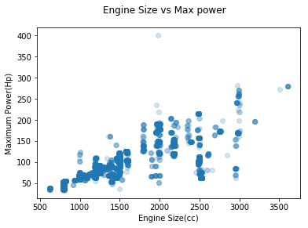

### Selling Price vs Fuel,Seller Type,Transmission,Seats and Car Ownership

1. We note that Diesel cars are quite expensive compared to Petro, CNG and LPG cars.
2. We note that cars sold by Dealers have a higher selling price compared to cars sold by individuals. We believe this is because dealers add a mark up the price of the used car.
3. We note that automatic cars are more expensive compared to manual cars.
4. There is a gradual increase in selling price for cars with Seats 4 to 7.We then see a gradual decline in the selling price for cars with more than 7 seats.
5. In terms of ownership, test drive cars are the most expensive. We then see a gradual decline in Selling Price as a used car is handed down from its first owner to second owner and thereafter to other owners.

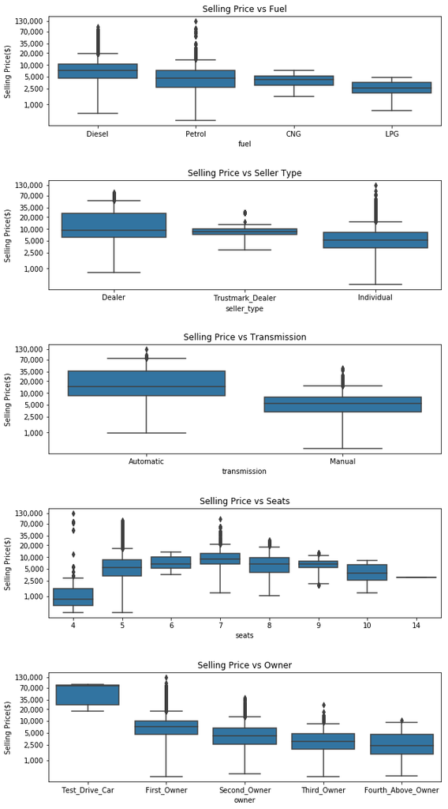

We will further examine each of the observations above in the next section

###### Test Drive Cars Selling Price

During investigation of the features Selling Price vs Owner, we noted that Test Drive cars had a higher selling price compared to other cars in the ownership category. We will visualize further the relationship between Selling Price and Onwership Feature. From the below visualization we note that Test Drive cars have been driven for the least kilometers amongst other owner categories. From our earlier observation, we have a negatively correlated relationship between Selling Price and Km_driven hence the observation.

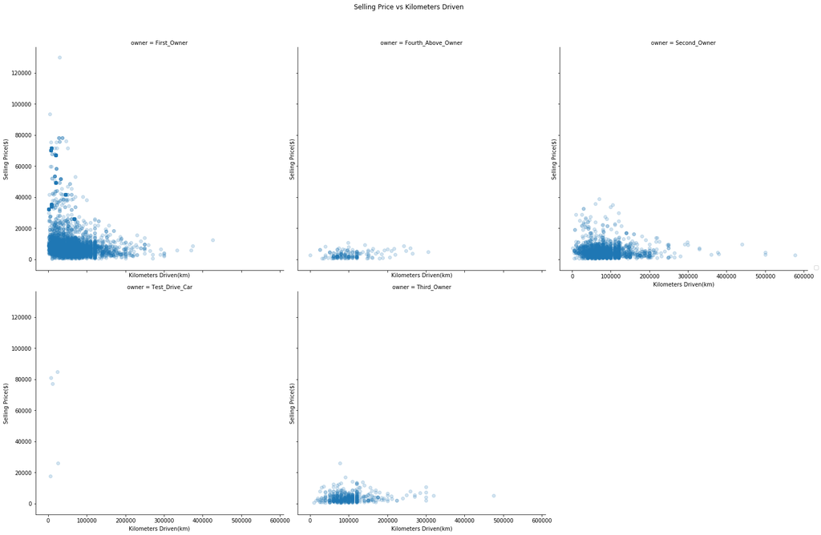

###### Selling Price Decrease for cars with more than 7 seats.

During investigation of the features Selling Price vs car seats, we noted a gradual decline in selling price for used cars with more than 7 seats. We will visualize cars with more than 7 seats to observe their characteristics and hence determine reason for the price decrease. From the below visualization we have noted:

1. Cars with more than 7 seats have very low Horse Power.These cars have less than 200hp.
2. A very big percentage of the cars with more than 7 seats are manual cars. We have noted that manual cars are much cheaper compared to automatic cars.
3. We have further noted that most of these cars are sold by individuals. From our analysis we have seen cars sold by individuals are cheaper than cars sold by dealers.

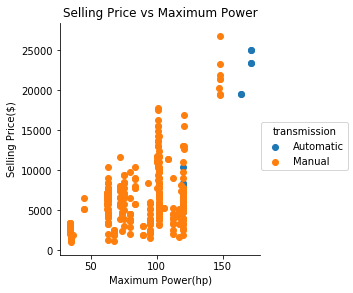

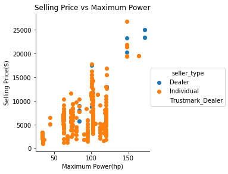

###### Automatic vs Manual Cars Selling Price

During investigation of the features selling price vs Transmission , we noted that Automatic cars are more expensive than Manual cars. In the real world, generally, automatic cars are more expensive due to the complexility involved in assembly. In our dataset, we will visualize further to understand the reason for this observation . From the below visualization , we can see that automatic vehicles have very high power compared to manual cars. We noted a positive correlation between selling Price and Max Power of a used car. This would explain the price difference.

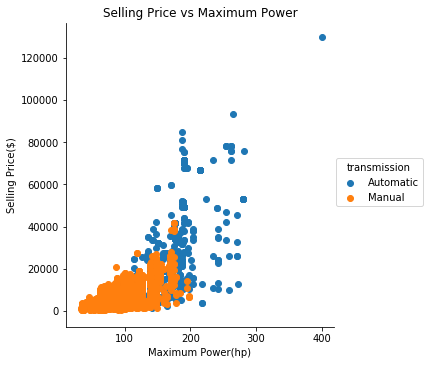

###### Diesel Cars vs Petrol Cars Selling Price

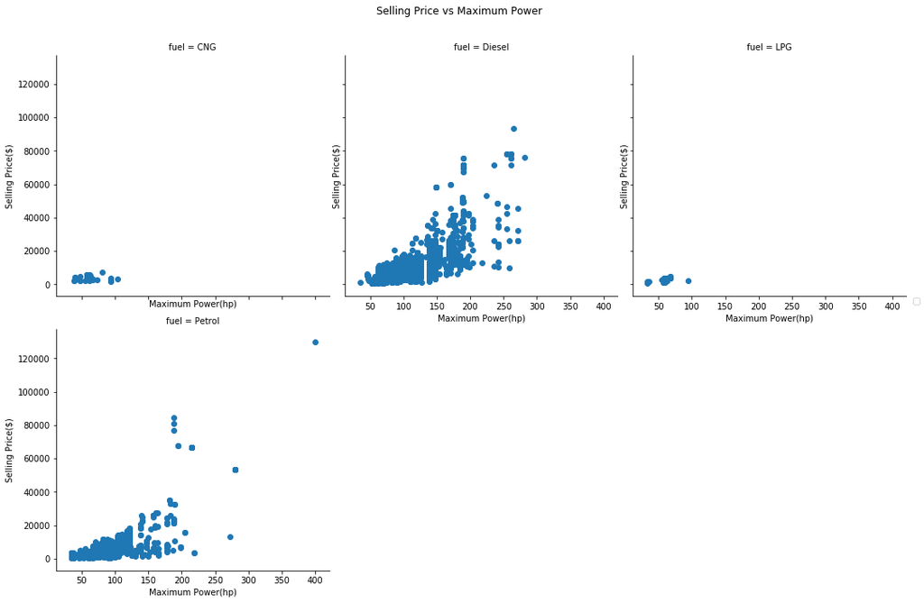